# Lab 8

Anna Ramji

2024-03-13

```r
knitr::opts_chunk$set(echo = TRUE, warning = FALSE, message = FALSE)
```

## Forest Cover Classification with SVM

In this week’s lab we are exploring the use of Support Vector Machines for multi-class classification. Specifically, you will be using cartographic variables to predict forest cover type (7 types).

Natural resource managers responsible for developing ecosystem management strategies require basic descriptive information including inventory data like forest cover type for forested lands to support their decision-making processes. However, managers generally do not have this type of data for in-holdings or neighboring lands that are outside their immediate jurisdiction. One method of obtaining this information is through the use of predictive models.

You task is build both an SVM and a random forest model and compare their performance on accuracy and computation time.

1. The data is available here: https://ucsb.box.com/s/ai5ost029enlguqyyn04bnlfaqmp8kn4

```r
library(tidymodels)
library(dplyr)
library(kernlab)
library(tidyverse)
library(here)

covtype_data <- read_csv(here("lab8", "data", "covtype_sample.csv"))
```

Explore the data.

```r
# commented out to avoid extraneous output
#summary(covtype_data)
# str(covtype_data)
```

- What kinds of features are we working with?

**We’re working with elevation, slope, aspect, physical characteristics of the topography and area, including: horizontal distance to roadways, hydrology, and fire points; hillshade at 9, noon, and 3; wilderness area (only three of these seem to be factors); and 41 soil types (Soil_Type, Soil_Type_1, …. Soil_Type_40). Currently these values are all doubles (numeric).**

**We are predicting on the outcome/classifier factor column, Cover_Type (we’ll need to set this as a factor) with 7 classes.**

```r
cover_type_summary <- covtype_data |>
  group_by(Cover_Type) |>
  summarize(count = n())

cover_type_summary |> gt::gt() |> gt::opt_stylize(style = 2, color = "green")
```

| Cover_Type | count |
| --- | --- |
| 1 | 3696 |
| 2 | 4870 |
| 3 | 586 |
| 4 | 40 |
| 5 | 157 |
| 6 | 330 |
| 7 | 321 |

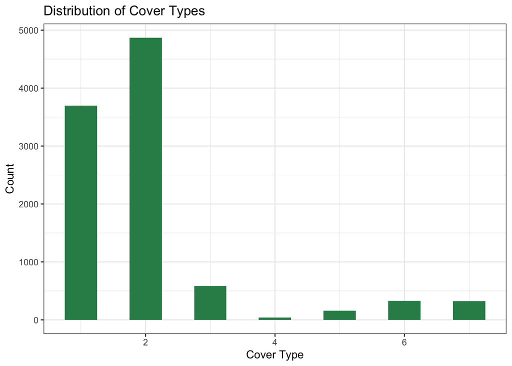

```r
# make histogram of cover types
cov_type_plot <- ggplot(data = covtype_data) +
  geom_histogram(aes(x = Cover_Type),
                 binwidth = 0.5,
                 fill = "seagreen") +
  theme_bw() +
  labs(x = "Cover Type",
       y = "Count",
       title = "Distribution of Cover Types")

# view plot
cov_type_plot
```

```r
# inspect to see if any columns have no observations
# covtype_data |>  select(where(~sum(.) == 0))
```

- Does anything stand out that will affect you modeling choices?

Hint: Pay special attention to the distribution of the outcome variable across the classes.

**There seems to be a notable class imbalance in the cover types, with significantly more of type 1 and 2, and significantly fewer of type 4 (and the rest, with 4 being the most extremely under-observed). This will affect my modeling choices in that I’ll need to incorporate a resampling technique (strata) to account for this and preserve that ratio. Based on other preliminary data exploration, I noticed that Soil_Type_15 has 0 observations, and some other types have very few observations (are very rarely observed). I will also incorporate `step_zv()` in my recipe to remove any columns with zero observations, as we won’t be able to run our model if some of the soil types have zero observations.**

2. Create the recipe and carry out any necessary preprocessing. Can you use the same recipe for both models?

```r
set.seed(1) # pseudo-randomness for reproducibility
# ======== Data preprocessing ===============================================
covtype_clean <- covtype_data |>
  janitor::clean_names() |>
  select(-c(where(~sum(.) == 0))) |>  # removing soil types that never appear in our dataset
  mutate(across(.cols = starts_with("soil"), as.factor)) |>
  mutate(across(.cols = c(11, 12, 13), as.factor)) |> # changing 3 wilderness area variables to factors
  mutate(cover_type = as.factor(cover_type))
   # find soil type columns that have no instances, remove those columns

# split the data ----
# initial split with 70:30 ratio, stratifying by factored outcome variable, cover_type
split <- initial_split(data = covtype_clean,
                       prop = 0.7, # 70:30 split
                       strata = cover_type) # stratifying by Cover_Type to preserve ratio in training and testing data sets

train <- training(split)
test <- testing(split)

# ========= Recipe ===========================================================

# specify a recipe that we can use for both models ----
# where we center to mean of 0 and scale to sd of 1
svm_recipe <- recipe(cover_type ~ ., data = covtype_clean) |>
  step_zv(all_predictors()) |> # remove columns w zero variables
  step_center(all_numeric_predictors()) |> # center
  step_scale(all_numeric_predictors()) |>  # scale (together, these normalize)
  step_dummy(all_nominal_predictors())  # create dummy variables from all factors


# ====== Model Specifications & Workflow =====================================

# --------- SVM RBF -----------------------------
# Create linear SVM model specification
svm_rbf <- svm_rbf(cost = tune()) |> # tune Cost
  set_engine("kernlab") |>
  set_mode("classification")

# SVM workflow
svm_wf <- workflow() |>
  add_model(svm_rbf) |>
  add_recipe(svm_recipe)


# ---------- Random Forest ----------------------
# set random forest tree model
tree_model <- rand_forest(
  mtry = tune(), # tune mtry
  trees = tune() # tune number of trees
) |>
  set_engine("ranger") |>
  set_mode("classification")

# random forest workflow
rf_workflow <- workflow() |>
  add_model(tree_model) |>
  add_recipe(svm_recipe) # using the same recipe
```

3. Create the folds for cross-validation.

```r
# setting up cv folds ----
# add in strata point here
cv_folds <- vfold_cv(train, v = 5, # 5 folds
                     strata = cover_type) # stratify by cover_type to retain ratio of observations in data sampling

# I will use the same cv_folds for both models
```

4. Tune the models. Choose appropriate parameters and grids. If the computational costs of tuning given your strategy are prohibitive, how might you work around this?

**To work around the higher computational costs, I used `doParallel::registerDoParallel(cores = 4)` and saved the output of each of my grid tuning steps as `.rda` objects, which I could then read in for later steps. This helps to make rendering more efficient, and is similar to what we’ve seen in discussion.**

```r
# ===================== Tuning =============================================

# I selected the parameters that I wanted to tune for each model in the preprocessing chunk above!
# for SVM RBF: Cost
# for RF: mtry and trees

# ----------- SVM RBF ------------------------------------
# set grid for svm
svm_grid <- grid_regular(cost(), # tuning for Cost
                          levels = 5)


# doParallel::registerDoParallel(cores = 4) # run in parallel

# commented out so that I can render in a reasonable amount of time
# system.time(
#   svm_rs <- tune_grid(
#     # could also replace w workflow
#     svm_wf,
#     resamples = cv_folds,
#     grid = svm_grid #  parameter combinations
#   )
# )
#   user  system elapsed
# 209.304   2.724  83.753

# saving output
# write_rds(svm_rs, here("lab8", "data", "svm_rs.rda"))

# reading in saved output from tune_grid
svm_rs <- read_rds(here("lab8", "data", "svm_rs.rda"))


# ----------- Random Forest --------------------------------


# commented out so that I can render in a reasonable amount of time
# doParallel::registerDoParallel(cores = 4) #build trees in parallel
#
# system.time(
# rf_cv_tune <- rf_workflow |>
#   tune_grid(resamples = cv_folds,
#             grid = 5) # use cross validation to tune mtry and trees parameters
#
# )

#   user  system elapsed
# 338.540   4.847 131.685

#write_rds(rf_cv_tune, here("lab8", "data", "rf_cv_tune.rda"))
# reading in rda file for faster knitting
rf_cv_tune <- read_rds(here("lab8", "data", "rf_cv_tune.rda"))


#rf_best_acc <- show_best(rf_cv_tune, n = 1, metric = "accuracy")
#rf_best_roc_auc <- show_best(rf_rs, n = 1, metric = "roc_auc")

#rf_best_acc
#rf_best_roc_auc # mtry 27, 1000 trees
```

5. Conduct final predictions for both models and compare their prediction performances and computation costs from part 4.

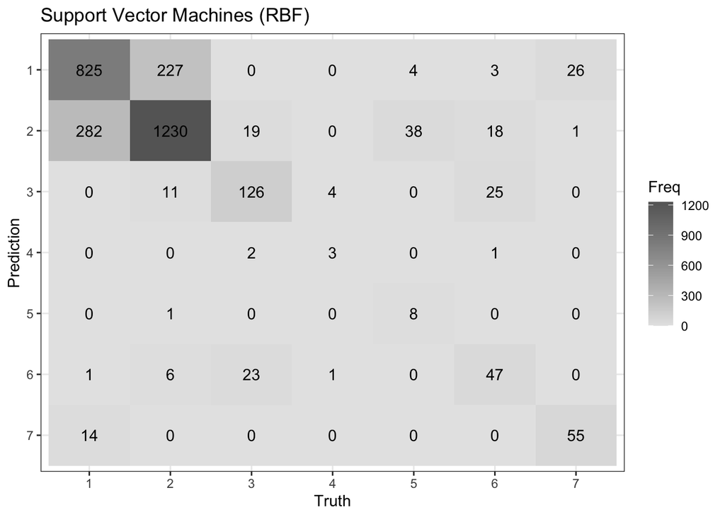

```r
# ================= SVM Final Prediction Performance =========================
# svm_rbf_fit <- svm_rbf |>
#   fit(cover_type ~ ., data = train)

# finalize workflow  ----
# select best cost parameter value based on optimizing roc_auc (rather than accuracy, as roc_auc is more informative, though we will just be comparing accuracy later on)
best_cost <- select_best(svm_rs, metric = "roc_auc")

# finalize workflow
svm_final <- finalize_workflow(svm_wf, best_cost)

# fit final workflow to use in augment steps
svm_fit_final <- svm_final |>  fit(train)
# maximum number of iterations reached 0.001501743 0.001473877

# last fit steps ----
svm_last_fit <- svm_final |> last_fit(split)

# collect metrics ----
svm_last_metrics <- svm_last_fit |>
  collect_metrics() |>
  mutate(model = "SVM RBF")

# augment steps ----

svm_augment <- augment(svm_fit_final, new_data = test)

# build confusion matrix
svm_conf_mat <- svm_augment |>
  conf_mat(truth = cover_type, estimate = .pred_class) |>
  autoplot(type = "heatmap") + #plot confusion matrix with heatmap
  theme_bw() + #change theme
  labs(title = "Support Vector Machines (RBF)") # update title

# view confusion matrix
svm_conf_mat
```

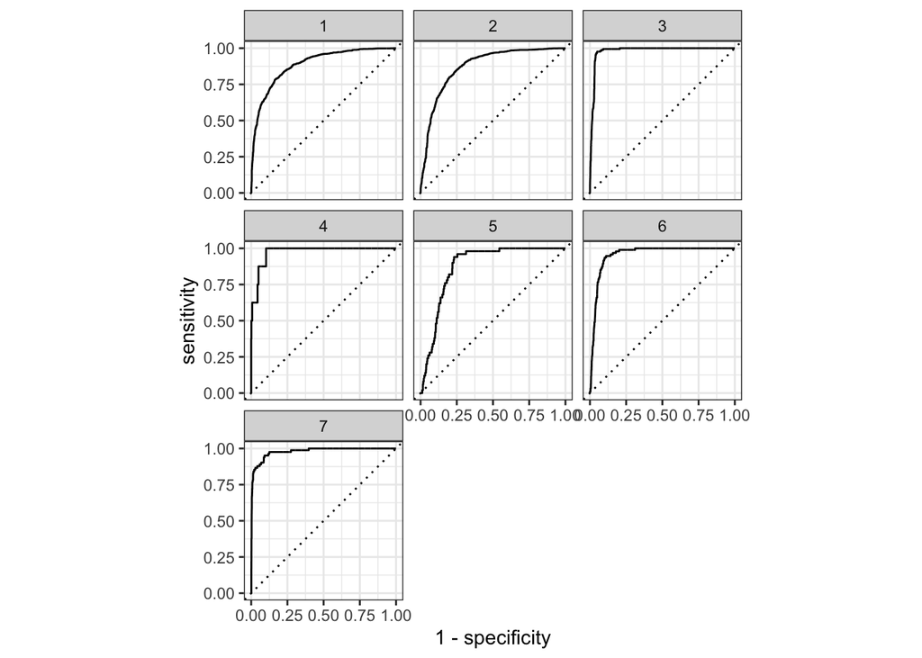

```r
# plot roc curves
svm_augment |>
  roc_curve(truth = cover_type, .pred_1, .pred_2, .pred_3, .pred_4, .pred_5, .pred_6, .pred_7) |>
  autoplot()
```

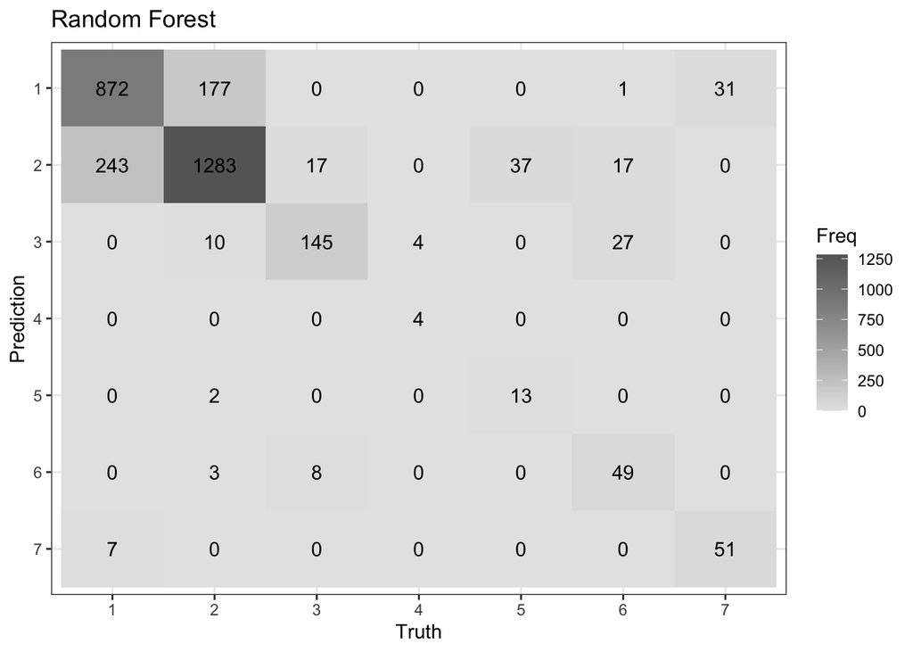

```r
# svm_augment |>
#   roc_auc(truth = cover_type, .pred_1, .pred_2, .pred_3, .pred_4, .pred_5, .pred_6, .pred_7) |>
#   gt::gt()

# svm_performance <- svm_augment |>
#   accuracy(truth = cover_type, .pred_class) |>
#   mutate(model = "SVM RBF")


# ============= Random Forest Final Prediction Performance ===================


# finalize workflow  ----
rf_final_wf<- finalize_workflow(rf_workflow,
                              select_best(rf_cv_tune, metric = "roc_auc"))


# assessing performance ----
fit_rf <- fit(rf_final_wf, train)

rf_augment <- augment(fit_rf, new_data = test)

# confusion matrix
rf_augment |>
  conf_mat(truth = cover_type, estimate = .pred_class) |>
  autoplot(type = "heatmap") + #plot confusion matrix with heatmap
  theme_bw() + #change theme
  labs(title = "Random Forest") # update title
```

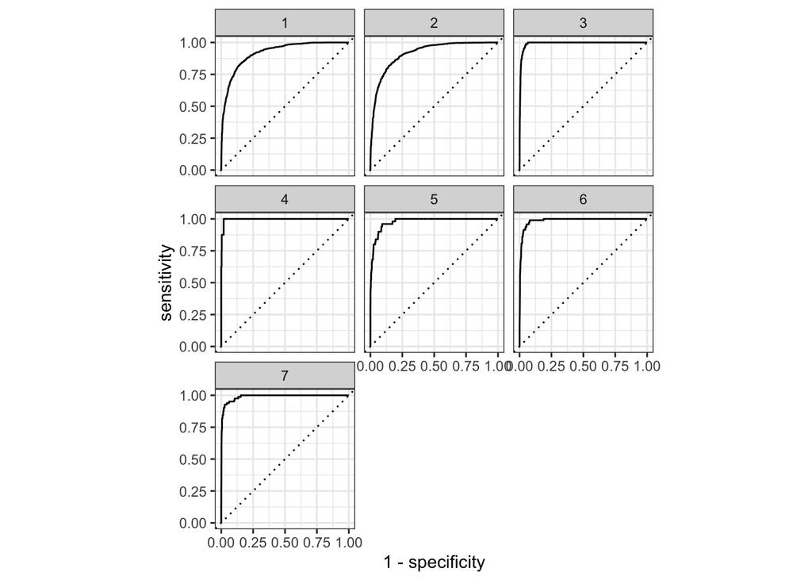

```r
# roc curve plots
rf_augment |>
  roc_curve(truth = cover_type, .pred_1, .pred_2, .pred_3, .pred_4, .pred_5, .pred_6, .pred_7) |>
  autoplot()
```

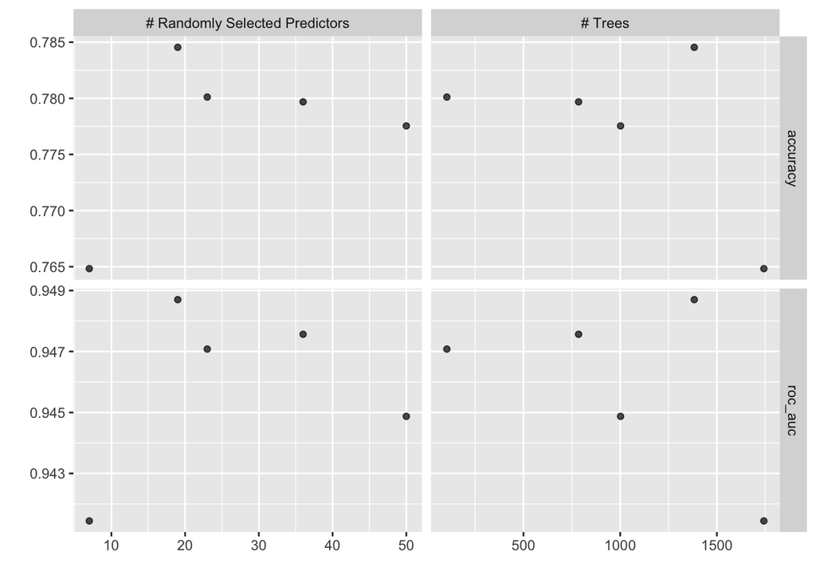

```r
# get last fit
rf_final_fit <- rf_final_wf |>
  last_fit(split) # takes an rsplit object

#rf_fit <- rf_final_roc_auc |> fit(Cover_Type ~ ., data = small_train)
rf_last_metrics <- rf_final_fit |>
  collect_metrics() |>
  mutate(model = "Random Forest")


# optional: visualizing performance on train and test data separately ----
autoplot(rf_cv_tune)
```

```r
# get train predictions
rf_train <- predict(fit_rf, train) |>  # get prediction probabilities for test
  # gets predicted class .pred_class (same type as your truth class)
  bind_cols(train) |>
  relocate(cover_type, .before = .pred_class)

rf_train_metrics <- rf_train |>
  metrics(cover_type, .pred_class) |>
  mutate(model = "Random Forest") |>
  mutate(set = "Train")

# get test predictions
rf_test <- predict(fit_rf, test) |>  # get prediction probabilities for test
  # gets predicted class .pred_class (same type as your truth class)
  bind_cols(test) |>
  relocate(cover_type, .before = .pred_class)

rf_test_metrics <- rf_test |>
  metrics(cover_type, .pred_class) |>
  mutate(model = "Random Forest") |>
  mutate(set = "Test")

rf_metrics <- rbind(rf_test_metrics, rf_train_metrics) |>
  relocate(model, .before = .metric) |>
  rename(metric = .metric,
         estimator = .estimator,
         estimate = .estimate
         ) |>
  select(-estimator)

rf_metrics |> gt::gt(
 # rowname_col = "metric",
  groupname_col = "model",
  row_group_as_column = TRUE) |>
  gt::opt_stylize(style = 2, color = "blue") |>
  gt::fmt_number(
    columns = "estimate",
    decimals = 4)  |>
  gt::cols_label(
    metric = "Metric",
    estimate = "Estimate",
    set = "Set"
  )
```

|  | Metric | Estimate | Set |
| --- | --- | --- | --- |
| Random Forest | accuracy | 0.8054 | Test |
|  | kap | 0.6751 | Test |
|  | accuracy | 0.9760 | Train |
|  | kap | 0.9612 | Train |

Here we can see that the model might be slightly overfit to the training data, as the performance drops by 17 percentage points for accuracy betweent the Train and Test data set model metrics.

```r
# ============ Compare Prediction Performances ===============================

compare_metrics <- rbind(svm_last_metrics, rf_last_metrics) |>
  select(-c(.config, .estimator)) |>
  relocate(model, .before = .metric) |>
  rename(metric = .metric,
        # estimator = .estimator,
         estimate = .estimate) #|
  #relocate(estimate, .before = estimator)

performance_table <- compare_metrics |> gt::gt(
  groupname_col = "model",
  row_group_as_column = TRUE
) |>
  gt::cols_label(
    model = "Model",
    metric = "Metric",
    estimate = "Estimate"
  ) |>
  gt::fmt_number(
    columns = "estimate",
    decimals = 4
  ) |>
  gt::opt_stylize(style = 2,
                  color = "gray")
performance_table
```

|  | Metric | Estimate |
| --- | --- | --- |
| SVM RBF | accuracy | 0.7651 |
|  | roc_auc | 0.8330 |
| Random Forest | accuracy | 0.8031 |
|  | roc_auc | 0.9603 |

```r
# ============ Compare computational costs =================================
# SVM computational time:

#   user  system elapsed
# 209.304   2.724  83.753


# Random Forest computational time:

#   user  system elapsed
# 338.540   4.847 131.685
```

- Which type of model do you think is better for this task?
- Why do you speculate this is the case?

**I think that the random forest model is better for this task, as it scores higher in accuracy (and roc_auc) than the (radial basis function) support vector machine.**

**This might be the case because random forest models are good at working through class imbalances, which is what we observed at the beginning in our preliminary data exploration. The outcome variable `cover_type` is observed at very uneven levels (far more observations for type 1 and 2 than the rest, with particularly low observations for type 4). SVM seems to generally be built for binary classification, and random forest seems to be better for multiclass classifying, which is what we are trying to do for this task.**